# DATA 621 Business Analytics & Data Mining

Homework #1 - Moneyball

Kyle Gilde

2/18/2018

[output not shown]

# Prompt and Data Overview

In this homework assignment, you will explore, analyze and model a data set containing approximately 2200 records.

Each record represents a professional baseball team from the years 1871 to 2006 inclusive. Each record has the performance of the team for the given year, with all of the statistics adjusted to match the performance of a 162 game season.

Your objective is to build a multiple linear regression model on the training data to predict the number of wins for the team. You can only use the variables given to you (or variables that you derive from the variables provided). Below is a short description of the variables of interest in the data set:

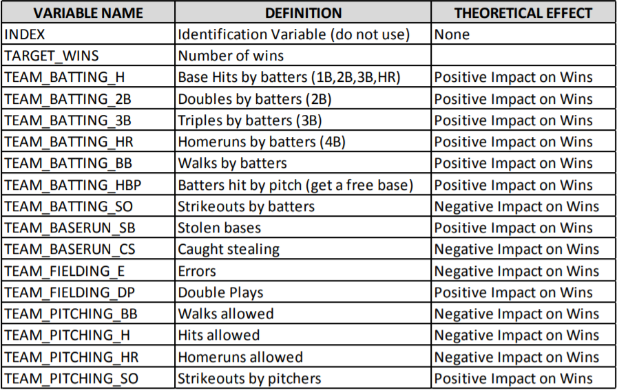

# 1. DATA EXPLORATION

## Non-visual exploration

**The data set contains 15 explanatory variables, and they can be categorized into four groups:**

1. 7 batting metrics
2. 2 baserunning metrics
3. 2 fielding metrics
4. 4 pitching metrics

### Data Inspection

Let’s take a look at the data’s non-statistical aspects.

- In the table below, we that the data set contains all integers.
- The data set has less than 10% complete cases.
- Six variables are missing values with TEAM_BATTING_HBP, TEAM_BASERUN_CS & TEAM_FIELDING_DP being the most sparse with 92%, 34% & 13% `NA`s, respectively.
- We will have to drop them or try to impute the missing values.

| vars | class_type | n_rows | complete_cases | NA_ct | NA_pct | unique_value_ct | most_common_values |
| --- | --- | --- | --- | --- | --- | --- | --- |
| TARGET_WINS | integer | 2276 | 191 | 0 | 0.0 | 108 | 83; 79; 85; 86; 87 |
| TEAM_BATTING_H | integer | 2276 | 191 | 0 | 0.0 | 569 | 1458; 1410; 1475; 1400 |
| TEAM_BATTING_2B | integer | 2276 | 191 | 0 | 0.0 | 240 | 227; 235; 259; 220 |
| TEAM_BATTING_3B | integer | 2276 | 191 | 0 | 0.0 | 144 | 35; 29; 38; 40 |
| TEAM_BATTING_HR | integer | 2276 | 191 | 0 | 0.0 | 243 | 21; 108; 17; 29 |
| TEAM_BATTING_BB | integer | 2276 | 191 | 0 | 0.0 | 533 | 502; 492; 497; 503 |
| TEAM_BATTING_SO | integer | 2276 | 191 | 102 | 4.5 | 823 | NA’s; 0; 952; 504 |
| TEAM_BASERUN_SB | integer | 2276 | 191 | 131 | 5.8 | 349 | NA’s; 65; 69; 73 |
| TEAM_BASERUN_CS | integer | 2276 | 191 | 772 | 33.9 | 129 | NA’s; 52; 46; 50; 37 |
| TEAM_BATTING_HBP | integer | 2276 | 191 | 2085 | 91.6 | 56 | NA’s; 54; 56; 72; 50 |
| TEAM_PITCHING_H | integer | 2276 | 191 | 0 | 0.0 | 843 | 1494; 1400; 1398; 1404 |
| TEAM_PITCHING_HR | integer | 2276 | 191 | 0 | 0.0 | 256 | 114; 22; 46; 138 |
| TEAM_PITCHING_BB | integer | 2276 | 191 | 0 | 0.0 | 535 | 536; 467; 495; 529 |
| TEAM_PITCHING_SO | integer | 2276 | 191 | 102 | 4.5 | 824 | NA’s; 0; 797; 825 |
| TEAM_FIELDING_E | integer | 2276 | 191 | 0 | 0.0 | 549 | 122; 134; 139; 116 |
| TEAM_FIELDING_DP | integer | 2276 | 191 | 286 | 12.6 | 145 | NA’s; 148; 156; 144 |

### Statistical Summary

|  | n | min | Q.1st | median | mean | Q.3rd | max | range | sd | se | skew | kurtosis |
| --- | --- | --- | --- | --- | --- | --- | --- | --- | --- | --- | --- | --- |
| TARGET_WINS | 2,276 | 0 | 71 | 82 | 80.8 | 92 | 146 | 146 | 15.8 | 0.3 | -0.4 | 1 |
| TEAM_BATTING_H | 2,276 | 891 | 1,383 | 1,454 | 1,469.3 | 1,537.2 | 2,554 | 1,663 | 144.6 | 3 | 1.6 | 7.3 |
| TEAM_BATTING_2B | 2,276 | 69 | 208 | 238 | 241.2 | 273 | 458 | 389 | 46.8 | 1 | 0.2 | 0 |
| TEAM_BATTING_3B | 2,276 | 0 | 34 | 47 | 55.2 | 72 | 223 | 223 | 27.9 | 0.6 | 1.1 | 1.5 |
| TEAM_BATTING_HR | 2,276 | 0 | 42 | 102 | 99.6 | 147 | 264 | 264 | 60.5 | 1.3 | 0.2 | -1 |
| TEAM_BATTING_BB | 2,276 | 0 | 451 | 512 | 501.6 | 580 | 878 | 878 | 122.7 | 2.6 | -1 | 2.2 |
| TEAM_BATTING_SO | 2,174 | 0 | 548 | 750 | 735.6 | 930 | 1,399 | 1,399 | 248.5 | 5.3 | -0.3 | -0.3 |
| TEAM_BASERUN_SB | 2,145 | 0 | 66 | 101 | 124.8 | 156 | 697 | 697 | 87.8 | 1.9 | 2 | 5.5 |
| TEAM_BASERUN_CS | 1,504 | 0 | 38 | 49 | 52.8 | 62 | 201 | 201 | 23 | 0.6 | 2 | 7.6 |
| TEAM_BATTING_HBP | 191 | 29 | 50.5 | 58 | 59.4 | 67 | 95 | 66 | 13 | 0.9 | 0.3 | -0.1 |
| TEAM_PITCHING_H | 2,276 | 1,137 | 1,419 | 1,518 | 1,779.2 | 1,682.5 | 30,132 | 28,995 | 1,406.8 | 29.5 | 10.3 | 141.8 |
| TEAM_PITCHING_HR | 2,276 | 0 | 50 | 107 | 105.7 | 150 | 343 | 343 | 61.3 | 1.3 | 0.3 | -0.6 |
| TEAM_PITCHING_BB | 2,276 | 0 | 476 | 536.5 | 553 | 611 | 3,645 | 3,645 | 166.4 | 3.5 | 6.7 | 97 |
| TEAM_PITCHING_SO | 2,174 | 0 | 615 | 813.5 | 817.7 | 968 | 19,278 | 19,278 | 553.1 | 11.9 | 22.2 | 671.2 |
| TEAM_FIELDING_E | 2,276 | 65 | 127 | 159 | 246.5 | 249.2 | 1,898 | 1,833 | 227.8 | 4.8 | 3 | 11 |
| TEAM_FIELDING_DP | 1,990 | 52 | 131 | 149 | 146.4 | 164 | 228 | 176 | 26.2 | 0.6 | -0.4 | 0.2 |

## Visual Exploration

### Boxplots

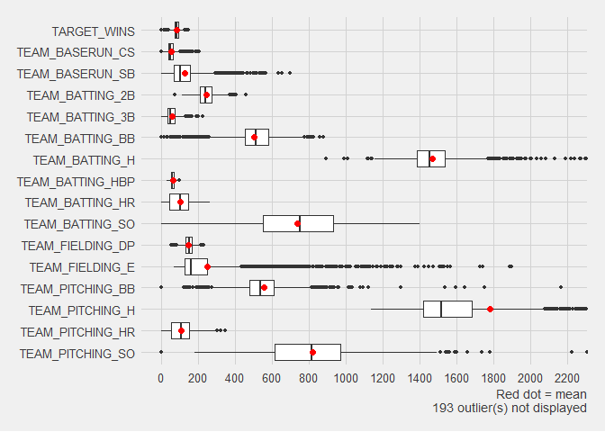

### Histograms

- The histograms below confirm that both the batting & pitching home-run variables are bimodal as well as the batting strike-out variable.
- Many variables have significant right skews.
- TEAM_BATTING_BB & TEAM_FIELDING_DP are left-skewed.
- The distributions for TEAM_BATTING_HBP, TEAM_BASERUN_CS & TEAM_FIELDING_DP are centered away from zero, so it seems unlikely that all the `NA`s are mislabelled zero values.

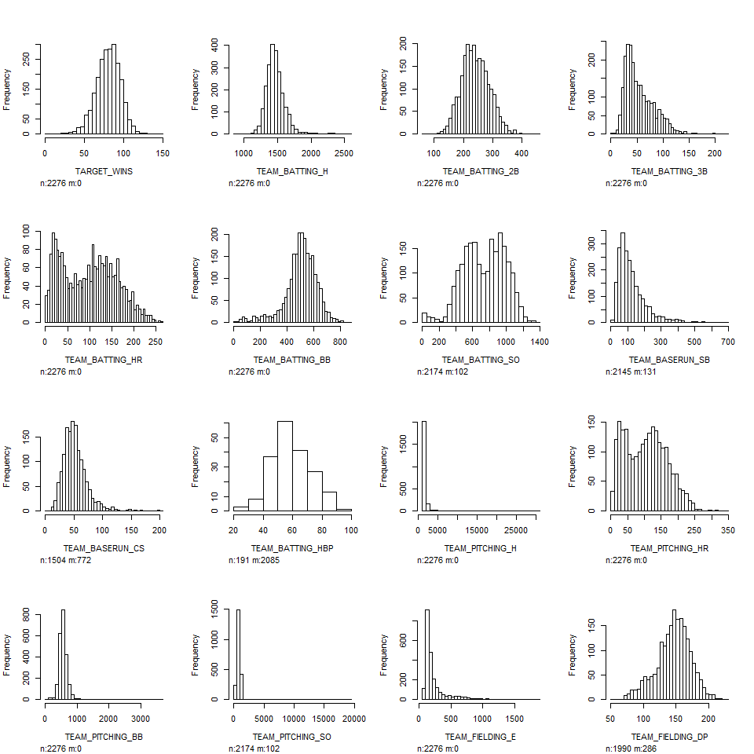

### Correlations

- In the correlation table and plot below, we see 4 pairs of highly correlated variables. They are corresponding metrics for batting and pitching: home runs, walks, strike outs & hits (rows 1-4). These may present multicollinearity issues in our modeling.
- Rows 8 to 11 show batting & pitching hits and walks are moderately correlated to our response variable. Let’s consider using them for one our models.

Top 12 Correlated Variable Pairs

|  | Var1 | Var2 | Correlation |
| --- | --- | --- | --- |
| 1 | TEAM_PITCHING_HR | TEAM_BATTING_HR | 0.9999 |
| 2 | TEAM_PITCHING_BB | TEAM_BATTING_BB | 0.9999 |
| 3 | TEAM_PITCHING_SO | TEAM_BATTING_SO | 0.9998 |
| 4 | TEAM_PITCHING_H | TEAM_BATTING_H | 0.9992 |
| 5 | TEAM_BASERUN_CS | TEAM_BASERUN_SB | 0.6247 |
| 6 | TEAM_BATTING_2B | TEAM_BATTING_H | 0.5618 |
| 7 | TEAM_PITCHING_H | TEAM_BATTING_2B | 0.5605 |
| 8 | TEAM_PITCHING_H | TARGET_WINS | 0.4712 |
| 9 | TEAM_BATTING_H | TARGET_WINS | 0.4699 |
| 10 | TEAM_BATTING_BB | TARGET_WINS | 0.4687 |
| 11 | TEAM_PITCHING_BB | TARGET_WINS | 0.4684 |
| 12 | TEAM_PITCHING_HR | TEAM_BATTING_BB | 0.4566 |

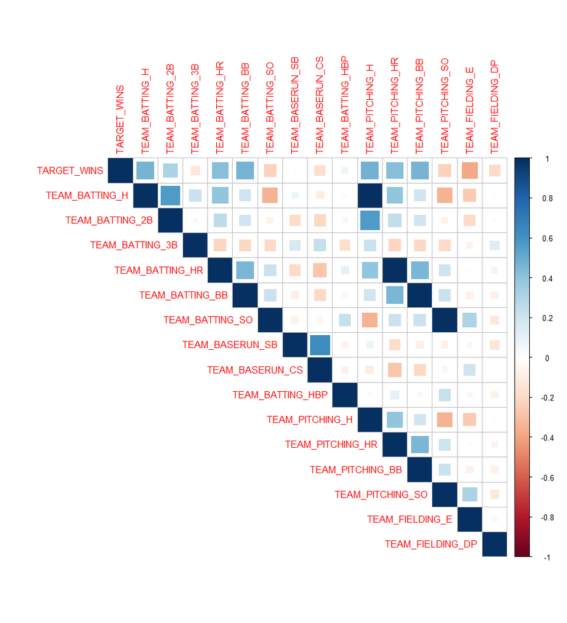

# 2. DATA PREPARATION

## Creating Bins

From the histograms and summary statitics, TEAM_PITCHING_H seems to have the extreme outliers, so let’s put these values into quintile bins to mitigate their effect.

```r
train_raw$TEAM_PITCHING_H <- bin_data(train_raw$TEAM_PITCHING_H, bins = 5, binType = "quantile")

levels(train_raw$TEAM_PITCHING_H) <- c("One","Two","Three","Four","Five")
```

## Missing Value Imputation

Let’s use the missForest package to do nonparametric missing-value imputation using Random Forest.

First, let’s try leaving in TEAM_BATTING_HPB, even though it has all of those `NA`s.

**When we check the out-of-the-bag error, we would like to the normalized root mean-squares error (NRMSE) near zero, which would indicate a well-fitted imputation. However, as suspected, the normalized root mean-squares error (NRMSE) for TEAM_BATTING_HBP is nearly twice as large as the next highest NRMSE. Let’s remove it and impute the missing values again.**

[Source: Accuracy and Errors for Models](http://rcompanion.org/handbook/G_14.html)

```
##   missForest iteration 1 in progress...done!
##   missForest iteration 2 in progress...done!
##   missForest iteration 3 in progress...done!
##   missForest iteration 4 in progress...done!
##   missForest iteration 5 in progress...done!
```

| variable | NA_ct | NA_pct | MSE | RMSE | NRMSE |
| --- | --- | --- | --- | --- | --- |
| TEAM_BATTING_HBP | 2085 | 91.61 | 194.34 | 13.94 | 0.21 |
| TEAM_FIELDING_DP | 286 | 12.57 | 341.17 | 18.47 | 0.10 |
| TEAM_BASERUN_CS | 772 | 33.92 | 178.53 | 13.36 | 0.07 |
| TEAM_BASERUN_SB | 131 | 5.76 | 1637.94 | 40.47 | 0.06 |
| TEAM_BATTING_SO | 102 | 4.48 | 1827.35 | 42.75 | 0.03 |
| TEAM_PITCHING_SO | 102 | 4.48 | 130365.14 | 361.06 | 0.02 |

**The remaining 5 imputed variables have NRMSE values have better fits and range from .02 to .11.**

```
##   missForest iteration 1 in progress...done!
##   missForest iteration 2 in progress...done!
##   missForest iteration 3 in progress...done!
##   missForest iteration 4 in progress...done!
##   missForest iteration 5 in progress...done!
```

| variable | NA_ct | NA_pct | MSE | RMSE | NRMSE |
| --- | --- | --- | --- | --- | --- |
| TEAM_FIELDING_DP | 286 | 12.57 | 346.87 | 18.62 | 0.11 |
| TEAM_BASERUN_CS | 772 | 33.92 | 185.08 | 13.60 | 0.07 |
| TEAM_BASERUN_SB | 131 | 5.76 | 1629.75 | 40.37 | 0.06 |
| TEAM_BATTING_SO | 102 | 4.48 | 2467.60 | 49.67 | 0.04 |
| TEAM_PITCHING_SO | 102 | 4.48 | 172102.31 | 414.85 | 0.02 |

# 3. BUILD MODELS

## Model 1: All Variables

First, let’s build a model with all variables.

```
##
## Call:
## lm(formula = TARGET_WINS ~ ., data = train_imputed)
##
## Residuals:
##     Min      1Q  Median      3Q     Max
## -55.389  -8.298   0.195   8.167  54.913
##
## Coefficients:
##                        Estimate Std. Error t value Pr(>|t|)
## (Intercept)          28.6409850  5.7749125   4.960 7.59e-07 ***
## TEAM_BATTING_H        0.0467974  0.0036512  12.817  < 2e-16 ***
## TEAM_BATTING_2B      -0.0080999  0.0091590  -0.884  0.37659
## TEAM_BATTING_3B       0.0248277  0.0166190   1.494  0.13533
## TEAM_BATTING_HR       0.0655984  0.0277124   2.367  0.01801 *
## TEAM_BATTING_BB       0.0123925  0.0052297   2.370  0.01789 *
## TEAM_BATTING_SO      -0.0195892  0.0026891  -7.285 4.43e-13 ***
## TEAM_BASERUN_SB       0.0470115  0.0054356   8.649  < 2e-16 ***
## TEAM_BASERUN_CS       0.0262674  0.0156964   1.673  0.09437 .
## TEAM_PITCHING_HTwo   -0.9872101  0.8882665  -1.111  0.26652
## TEAM_PITCHING_HThree -1.0974513  0.9532332  -1.151  0.24973
## TEAM_PITCHING_HFour  -4.3120963  1.1048503  -3.903 9.78e-05 ***
## TEAM_PITCHING_HFive  -3.1433220  1.4102628  -2.229  0.02592 *
## TEAM_PITCHING_HR      0.0291162  0.0247491   1.176  0.23954
## TEAM_PITCHING_BB     -0.0031523  0.0035931  -0.877  0.38041
## TEAM_PITCHING_SO      0.0024559  0.0009026   2.721  0.00656 **
## TEAM_FIELDING_E      -0.0322373  0.0023362 -13.799  < 2e-16 ***
## TEAM_FIELDING_DP     -0.1123643  0.0140611  -7.991 2.11e-15 ***
## ---
## Signif. codes:  0 '***' 0.001 '**' 0.01 '*' 0.05 '.' 0.1 ' ' 1
##
## Residual standard error: 12.65 on 2258 degrees of freedom
## Multiple R-squared:  0.3602, Adjusted R-squared:  0.3554
## F-statistic: 74.77 on 17 and 2258 DF,  p-value: < 2.2e-16
```

In the model output above, we notice the following:

- Of the 14 continuous & intercept variables, 9 have statistically significant p-values at the 5% significance level. In the 3rd model, we will explore which of the variables are actually necessary to a parsimonious model.
- Only 2 out of the 4 TEAM_PITCHING_H quintile dummy variables are statistically significant, so let’s check an ANOVA summary to make sure that the group means are significantly different. The F-statistic’s p-value is near zero, so we would reject the null hypothesis that the means are equal and keep the dummy variables in the model.

```
##                   Df Sum Sq Mean Sq F value Pr(>F)
## TEAM_PITCHING_H    4  22687    5672   23.77 <2e-16 ***
## Residuals       2271 541810     239
## ---
## Signif. codes:  0 '***' 0.001 '**' 0.01 '*' 0.05 '.' 0.1 ' ' 1
```

## Model 2: Only Highly Correlated Variables

From our Correlated Variable Pairs table, let’s use only the 4 explanatory variables that were most correlated with the response variable.

```
##               Var1        Var2 Correlation
## 1  TEAM_PITCHING_H TARGET_WINS   0.4712343
## 2   TEAM_BATTING_H TARGET_WINS   0.4699467
## 3  TEAM_BATTING_BB TARGET_WINS   0.4686879
## 4 TEAM_PITCHING_BB TARGET_WINS   0.4683988
```

```
##
## Call:
## lm(formula = TARGET_WINS ~ TEAM_PITCHING_H + TEAM_BATTING_H +
##     TEAM_BATTING_BB + TEAM_PITCHING_BB, data = train_imputed)
##
## Residuals:
##     Min      1Q  Median      3Q     Max
## -59.728  -8.963   0.394   9.085  65.012
##
## Coefficients:
##                       Estimate Std. Error t value Pr(>|t|)
## (Intercept)          -6.052105   3.788542  -1.597  0.11030
## TEAM_PITCHING_HTwo    0.092667   0.955466   0.097  0.92275
## TEAM_PITCHING_HThree -0.034295   1.005300  -0.034  0.97279
## TEAM_PITCHING_HFour  -3.315098   1.095721  -3.025  0.00251 **
## TEAM_PITCHING_HFive  -1.341073   1.301417  -1.030  0.30290
## TEAM_BATTING_H        0.049052   0.002722  18.018  < 2e-16 ***
## TEAM_BATTING_BB       0.036671   0.003172  11.563  < 2e-16 ***
## TEAM_PITCHING_BB     -0.004882   0.002201  -2.218  0.02667 *
## ---
## Signif. codes:  0 '***' 0.001 '**' 0.01 '*' 0.05 '.' 0.1 ' ' 1
##
## Residual standard error: 13.87 on 2268 degrees of freedom
## Multiple R-squared:  0.2275, Adjusted R-squared:  0.2251
## F-statistic: 95.41 on 7 and 2268 DF,  p-value: < 2.2e-16
```

In the Model #2 output above, we notice the following:

- All 3 continuous variables are statistically significant, but this time the intercept is not.
- Only 1 of the 4 TEAM_PITCHING_H dummy variables is statistically significant.
- We would expect a negative coefficient for Walks Allowed and positive ones for Batting Walks & Batting Hits. However, 1 of the 4 Hits Allowed dummy variables does not have a negative coefficient, and this unexpected coefficient sign may indicate that we still have some collinearity.
- At 0.2251, the adjusted $R^2$ indicates that this model explains less of variance in the response variable than Model #1.
- At 95, the F-statistic is larger than model #1, and the model’s p-value is near zero. If the model’s diagnostics are sufficient, these values indicate that we would reject the null hypothesis that there is no relationship between the explanatory & response variables.

## Model 3: Backwards Elimination

```
##
## Call:
## lm(formula = TARGET_WINS ~ TEAM_BATTING_H + TEAM_BATTING_HR +
##     TEAM_BATTING_SO + TEAM_BASERUN_SB + TEAM_FIELDING_E, data = train_imputed)
##
## Residuals:
##     Min      1Q  Median      3Q     Max
## -52.551  -8.678   0.128   8.514  53.122
##
## Coefficients:
##                  Estimate Std. Error t value Pr(>|t|)
## (Intercept)     25.629114   4.237642   6.048 1.71e-09 ***
## TEAM_BATTING_H   0.039267   0.002512  15.631  < 2e-16 ***
## TEAM_BATTING_HR  0.071958   0.008755   8.219 3.41e-16 ***
## TEAM_BATTING_SO -0.014925   0.002190  -6.814 1.21e-11 ***
## TEAM_BASERUN_SB  0.066361   0.003767  17.616  < 2e-16 ***
## TEAM_FIELDING_E -0.030775   0.001665 -18.482  < 2e-16 ***
## ---
## Signif. codes:  0 '***' 0.001 '**' 0.01 '*' 0.05 '.' 0.1 ' ' 1
##
## Residual standard error: 12.93 on 2270 degrees of freedom
## Multiple R-squared:  0.3273, Adjusted R-squared:  0.3258
## F-statistic: 220.9 on 5 and 2270 DF,  p-value: < 2.2e-16
```

In the Model #3 output above, we notice the following:

- All 5 continuous variables & and the intercept are statistically significant. Their p-values are near zero.
- Unlike the previous models, we do not have any unexpected coefficient signs, which means that we have removed at least some of the multilinearity.
- At 0.3258, the adjusted $R^2$ indicates that this model explains 33% of the variance in the response variable.
- At 221, the F-statistic is larger than the other 2 models, and the model’s p-value is near zero. If the model’s diagnostics are sufficient, these values indicate that we would reject the null hypothesis that there is no relationship between the explanatory & response variables.

# 4. SELECT MODEL

## Evaluation

The table below summarizes the 3 models.

- While Model #1 has the highest adjusted R-squared, it also had 5 variables that were not statistically significant, and 4 variables with unexpected signs, which indicated multicollinearity issues.
- Model #2 used fewer variables, but the intercept coefficient was not statistically significant. We also saw some evidence of collinearity.
- **Of the 3, Model #3 is the best.** Removing the non-significant and collinear variables makes it more parsimonious with an adjusted R-squared that is less than Model #1 but much greater than Model #2. This model’s F-statistic is also significantly larger than the other 2. Additionally, the difference between Model #3’s predicted R-squared and R-squared is smaller than the other models, giving us more confidence that the model is not overfit.

| model_name | n_predictors | pred.r.squared | r.squared | adj.r.squared | sigma | statistic | p.value | df |
| --- | --- | --- | --- | --- | --- | --- | --- | --- |
| mod1 | 14 | 0.3326 | 0.3602 | 0.3554 | 12.6474 | 74.7676 | 0 | 18 |
| mod2 | 4 | 0.2146 | 0.2275 | 0.2251 | 13.8663 | 95.4145 | 0 | 8 |
| mod3 | 5 | 0.3225 | 0.3273 | 0.3258 | 12.9336 | 220.9222 | 0 | 6 |

## Residual Plots

- In the Q-Q plot, we see some deviations for the normal distribution at the ends. Some of the extreme cases have been labeled. However, as the LMR text suggests, perhaps we can relax the normality assumption since we have more than 2200 observations.
- In the residuals-fitted and standardzied residuals-fitted plots, the best fitted line has a curve in the main cluster, which indicates that we do not have constant variance.
- Ideally, prior to making any inferences, we would want to attempt to transform the data in order to better meet the regression assumptions.

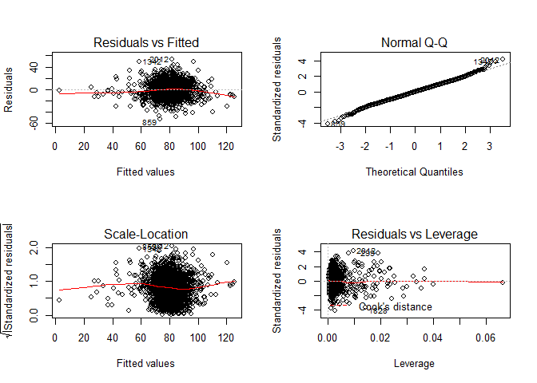

## Test Model

### Explore

Let’s load the data, and look at our `NA` rates.

| vars | class_type | n_rows | complete_cases | NA_ct | NA_pct | unique_value_ct | most_common_values |
| --- | --- | --- | --- | --- | --- | --- | --- |
| TEAM_BATTING_H | integer | 259 | 19 | 0 | 0.0 | 199 | 1420; 1450; 1381; 1385 |
| TEAM_BATTING_2B | integer | 259 | 19 | 0 | 0.0 | 137 | 218; 223; 225; 239 |
| TEAM_BATTING_3B | integer | 259 | 19 | 0 | 0.0 | 91 | 36; 39; 46; 52; 53 |
| TEAM_BATTING_HR | integer | 259 | 19 | 0 | 0.0 | 141 | 130; 29; 98; 18 |
| TEAM_BATTING_BB | integer | 259 | 19 | 0 | 0.0 | 185 | 506; 511; 435; 463 |
| TEAM_BATTING_SO | integer | 259 | 19 | 18 | 6.9 | 207 | NA’s; 629; 677; 1008 |
| TEAM_BASERUN_SB | integer | 259 | 19 | 13 | 5.0 | 154 | NA’s; 72; 54; 59 |
| TEAM_BASERUN_CS | integer | 259 | 19 | 87 | 33.6 | 69 | NA’s; 56; 32; 39; 40 |
| TEAM_BATTING_HBP | integer | 259 | 19 | 240 | 92.7 | 18 | NA’s; 62; 63; 42; 46 |
| TEAM_PITCHING_H | integer | 259 | 19 | 0 | 0.0 | 210 | 1450; 1453; 1457; 1489 |
| TEAM_PITCHING_HR | integer | 259 | 19 | 0 | 0.0 | 144 | 62; 112; 25; 43 |
| TEAM_PITCHING_BB | integer | 259 | 19 | 0 | 0.0 | 199 | 521; 438; 471; 474 |
| TEAM_PITCHING_SO | integer | 259 | 19 | 18 | 6.9 | 206 | NA’s; 527; 554; 715 |
| TEAM_FIELDING_E | integer | 259 | 19 | 0 | 0.0 | 168 | 130; 137; 126; 135 |
| TEAM_FIELDING_DP | integer | 259 | 19 | 31 | 12.0 | 91 | NA’s; 146; 174; 156; 157 |

### Transform & Impute Missing Values

We see similar patterns of missing values, so let’s do the following:

- bin TEAM_PITCHING_H
- drop the sparsely populated TEAM_BATTING_HBP
- and impute the missing values

Since we have fewer cases, the NRMSE values are a little higher with the test data.

```
##   missForest iteration 1 in progress...done!
##   missForest iteration 2 in progress...done!
##   missForest iteration 3 in progress...done!
##   missForest iteration 4 in progress...done!
```

[output not shown]

```r
test_results <- predict(mod3, newdata = test_imputed)
```

# Code Appendix

```r
knitr::opts_chunk$set(
                      error = FALSE
                      ,message = FALSE
                      #,tidy = TRUE
                      ,cache = TRUE
                      )
#required packages
packages <- c("prettydoc", "psych", "knitr", "tidyverse", "ggthemes", "corrplot", "Hmisc", "data.table", "missForest", "mltools", "htmlTable", "broom", "MLmetrics")

#see if we need to install any of them
installed_and_loaded <- function(pkg){
  #CODE SOURCE: https://gist.github.com/stevenworthington/3178163
  new.pkg <- pkg[!(pkg %in% installed.packages()[, "Package"])]
  if (length(new.pkg)) install.packages(new.pkg, dependencies = TRUE)
  sapply(pkg, require, character.only = TRUE, quietly = TRUE, warn.conflicts = FALSE)
}

#excute function and display the loaded packages
data.frame(installed_and_loaded(packages))
train_raw <- read.csv("https://raw.githubusercontent.com/kylegilde/D621-Data-Mining/master/HW1%20Moneyball/moneyball-training-data.csv")

train_raw <- train_raw %>% select(-INDEX)

test_raw <- dplyr::select(read.csv("https://raw.githubusercontent.com/kylegilde/D621-Data-Mining/master/HW1%20Moneyball/moneyball-evaluation-data.csv"), - INDEX)

set.seed(5)


metadata <- function(df){
  #Takes a data frame & Checks NAs, class types, inspects the unique values
  df_len <- nrow(df)
  NA_ct = as.vector(rapply(df, function(x) sum(is.na(x))))

  #create dataframe
  df_metadata <- data.frame(
    vars = names(df),
    class_type = rapply(lapply(df, class), function(x) x[[1]]),
    n_rows = rapply(df, length),
    complete_cases = sum(complete.cases(df)),
    NA_ct = NA_ct,
    NA_pct = NA_ct / df_len * 100,
    unique_value_ct = rapply(df, function(x) length(unique(x))),
    most_common_values = rapply(df, function(x) str_replace(paste(names(sort(summary(as.factor(x)), decreasing=T))[1:5], collapse = '; '), "\\(Other\\); ", ""))
  )
 rownames(df_metadata) <- NULL
 return(df_metadata)
}

meta_df <- metadata(train_raw)


kable(meta_df, digits = 1)
metrics <- function(df){
  ###Creates summary metrics table
  metrics_only <- df[, which(rapply(lapply(df, class), function(x) x[[1]]) %in% c("numeric", "integer"))]

  df_metrics <- psych::describe(metrics_only, quant = c(.25,.75))

  df_metrics <-
    dplyr::select(df_metrics, n, min, Q.1st = Q0.25, median, mean, Q.3rd = Q0.75,
    max, range, sd, se, skew, kurtosis
  )

  return(df_metrics)
}

metrics_df <- metrics(train_raw)

kable(metrics_df, digits = 1, format.args = list(big.mark = ',', scientific = F, drop0trailing = T))
#calculate some parameters to deal with the outliers
train_stacked <- na.omit(stack(train_raw))
bpstats <- boxplot(values ~ ind, data = train_stacked, plot = F)$stats
ylimits <- c(0, ceiling(max(bpstats) / 200)) * 200
ybreaks <- seq(ylimits[1], ylimits[2], by = 200)
outliers_not_shown <- paste(sum(train_stacked$values > max(ylimits)), "outlier(s) not displayed")

ggplot(data = train_stacked, mapping = aes(x = ind, y = values)) +
  geom_boxplot(outlier.size = 1) +
  labs(caption = paste("Red dot = mean", outliers_not_shown, sep = "\n")) +
  scale_x_discrete(limits = rev(levels(train_stacked$ind))) +
  scale_y_continuous(breaks = ybreaks) +
  stat_summary(fun.y=mean, geom="point", size=2, color = "red") +
  coord_flip(ylim = ylimits) +
  theme_fivethirtyeight()


hist.data.frame(train_raw)
cormatrix <- cor(drop_na(train_raw))

#find the top correlations
cor_df <- data.frame(Var1=rownames(cormatrix)[row(cormatrix)],
                     Var2=colnames(cormatrix)[col(cormatrix)],
                     Correlation=c(cormatrix))


corr_list <-
  cor_df %>%
  filter(Var1 != Var2) %>%
  arrange(-Correlation)

#dedupe the rows
sort_rows <- t(apply(corr_list, 1, sort, decreasing = T))
fin_list <- corr_list[!duplicated(sort_rows), ]
rownames(fin_list) <- 1:nrow(fin_list)
#print table
kable(head(fin_list, 12), digits=4, row.names = T, caption = "Top 12 Correlated Variable Pairs")

#https://stackoverflow.com/questions/28035001/transform-correlation-matrix-into-dataframe-with-records-for-each-row-column-pai

#plot
corrplot(cormatrix, method = "square", type = "upper")

train_raw$TEAM_PITCHING_H <- bin_data(train_raw$TEAM_PITCHING_H, bins = 5, binType = "quantile")

levels(train_raw$TEAM_PITCHING_H) <- c("One","Two","Three","Four","Five")

impute_missing <- missForest(train_raw, variablewise = T)

# check imputation error
impute_df <- cbind(meta_df,
                   range = metrics_df$range,
                   MSE = as.numeric(impute_missing$OOBerror),
                   variable = names(impute_missing$ximp)) %>%
  select(variable, NA_ct, NA_pct, MSE) %>%
  mutate(RMSE = sqrt(as.numeric(impute_missing$OOBerror)),
         NRMSE = sqrt(as.numeric(impute_missing$OOBerror))/metrics_df$range) %>%
  filter(MSE > 0) %>%
  arrange(-NRMSE)

kable(impute_df, digits = 2)
train_raw_less_one <- select(train_raw, -TEAM_BATTING_HBP)
impute_missing <- missForest(train_raw_less_one, variablewise = T)

# check imputation error
impute_df <- cbind(metadata(train_raw_less_one),
                   range = rapply(impute_missing$ximp, max) - rapply(impute_missing$ximp, min),
                   MSE = as.numeric(impute_missing$OOBerror),
                   variable = names(impute_missing$ximp)) %>%
  select(variable, NA_ct, NA_pct, MSE) %>%
  mutate(RMSE = sqrt(as.numeric(impute_missing$OOBerror)),
         NRMSE = sqrt(as.numeric(impute_missing$OOBerror))/(rapply(impute_missing$ximp, max) - rapply(impute_missing$ximp, min))) %>%
  filter(MSE > 0) %>%
  arrange(-NRMSE)

kable(impute_df, digits = 2)

train_imputed <- impute_missing$ximp
class(train_imputed$TEAM_PITCHING_H) <- "factor"

mod1 <- lm(TARGET_WINS ~ ., data = train_imputed)

summary(mod1)
summary(aov(TARGET_WINS~TEAM_PITCHING_H, data = train_imputed))
filter(fin_list, Var2 == "TARGET_WINS")[1:4,]

mod2 <- lm(TARGET_WINS ~ TEAM_PITCHING_H + TEAM_BATTING_H + TEAM_BATTING_BB + TEAM_PITCHING_BB, data = train_imputed)

summary(mod2)

mod3 <- update(mod1, .~. -TEAM_FIELDING_DP -TEAM_BATTING_2B -TEAM_BASERUN_CS -TEAM_PITCHING_HR, data = train_imputed)
#summary(mod3) #R-sq = 0.334

#remove TEAM_PITCHING_BB at 0.598258
mod3 <- update(mod3, .~. -TEAM_PITCHING_BB, data = train_imputed)
#summary(mod3) #new R-sq = 0.3342

#remove TEAM_BATTING_BB at 0.169551
mod3 <- update(mod3, .~. -TEAM_BATTING_BB, data = train_imputed)
#summary(mod3) #new R-sq = 0.3341

#remove TEAM_PITCHING_H
mod3 <- update(mod3, .~. -TEAM_PITCHING_H, data = train_imputed)
#summary(mod3) #new R-sq = 0.3284

#remove TEAM_PITCHING_SO, it appears collinear
mod3 <- update(mod3, .~. -TEAM_PITCHING_SO, data = train_imputed)
#summary(mod3) #new R-sq = 0.3273

#remove TEAM_BATTING_3B,
mod3 <- update(mod3, .~. -TEAM_BATTING_3B, data = train_imputed)
summary(mod3) #new R-sq = 0.3273


PRESS <- function(linear.model) {
  #source:  https://gist.github.com/tomhopper/8c204d978c4a0cbcb8c0#file-press-r
  #' calculate the predictive residuals
  pr <- residuals(linear.model)/(1-lm.influence(linear.model)$hat)
  #' calculate the PRESS
  PRESS <- sum(pr^2)

  return(PRESS)
}
pred_r_squared <- function(linear.model) {
  #source: https://gist.github.com/tomhopper/8c204d978c4a0cbcb8c0#file-pred_r_squared-r
  #' Use anova() to get the sum of squares for the linear model
  lm.anova <- anova(linear.model)
  #' Calculate the total sum of squares
  tss <- sum(lm.anova$'Sum Sq')
  # Calculate the predictive R^2
  pred.r.squared <- 1-PRESS(linear.model)/(tss)

  return(pred.r.squared)
}


model_summary <- function(model, y_var) {
    ### Summarizes the model's key statistics in one row
    df_summary <- glance(summary(model))
    model_name <- deparse(substitute(model))
    n_predictors <- ncol(model$model) - 1
    pred.r.squared <- pred_r_squared(model)
    df_summary <- cbind(model_name, n_predictors, pred.r.squared, df_summary)
    return(df_summary)
}
mod_sum_df1 <- model_summary(mod1, "TARGET_WINS")
mod_sum_df2 <- model_summary(mod2, "TARGET_WINS")
mod_sum_df3 <- model_summary(mod3, "TARGET_WINS")

kable(all_results <- rbind(mod_sum_df1, mod_sum_df2, mod_sum_df3), digits = 4)
par(mfrow=c(2,2))
plot(mod3)
kable(metadata(test_raw), digits = 1)

test_raw$TEAM_PITCHING_H <- bin_data(test_raw$TEAM_PITCHING_H, bins = 5, binType = "quantile")

levels(test_raw$TEAM_PITCHING_H) <- c("One","Two","Three","Four","Five")

test_raw_less_one <- select(test_raw, -TEAM_BATTING_HBP)

impute_missing_test <- missForest(test_raw_less_one, variablewise = T)

# check imputation error
impute_df <- cbind(metadata(test_raw_less_one),
                   range = rapply(impute_missing_test$ximp, max) - rapply(impute_missing_test$ximp, min),
                   MSE = as.numeric(impute_missing_test$OOBerror),
                   variable = names(impute_missing_test$ximp)
                   ) %>%
  select(variable, NA_ct, NA_pct, MSE) %>%
  mutate(RMSE = sqrt(as.numeric(impute_missing_test$OOBerror)),
         NRMSE = sqrt(as.numeric(impute_missing_test$OOBerror))/(rapply(impute_missing_test$ximp, max) - rapply(impute_missing_test$ximp, min))) %>%
  filter(MSE > 0) %>%
  arrange(-NRMSE)

kable(impute_df, digits = 2)

test_imputed <- impute_missing$ximp
class(test_imputed$TEAM_PITCHING_H) <- "factor"
test_results <- predict(mod3, newdata = test_imputed)
```